# Diffusion of Work Injury Law

*overview: steps in this script*

1. read networks. All data should already be standardized a) cultural spheres b) trade networks c) colonial ties (cross-sectional) => will be changed? b) distance/prox. between capitals (cross-sectional)
2. read explanatory variables, basics
3. read years of >social policy introduction< for each project
4. create netdiffuseR objects => generate plots if you like# repeat 4. for each network!
5. get the respective exposure variables and time-of-adoption (toa)
6. create process-time control
7. combine the relevant information into one data frame
8. !! estimate discrete-time logistic hazard model !!

```r
# Clean up environment
rm(list = ls(all = T))

# note you must have pacman installed for this to run
# install.packages('pacman')
# library('pacman')

pacman::p_load('netdiffuseR','stargazer','tidyverse','dplyr','countrycode')

# set up a working directory
# Recommended to set up in C:/GitHub/work_inj_diffuse/

wd <- "C:/GitHub/work_inj_diff"


# this is a function to load and save files from the working directory
wdir <- function(x){
  paste(wd,x, sep = "/")
}
```

## Get Data

#### Networkdata sources

http://www.barkhof.uni-bremen.de/~mwindzio/edgelist_cultural_spheres.zip http://www.barkhof.uni-bremen.de/~mwindzio/COW_trade_consolidated.zip http://www.barkhof.uni-bremen.de/~mwindzio/trade_existence_dummy.csv http://www.barkhof.uni-bremen.de/~mwindzio/capital_distance_edgelist.zip http://www.barkhof.uni-bremen.de/~mwindzio/vdem_gdp_pc_INTERPOLATED_consolidated.csv http://www.barkhof.uni-bremen.de/~mwindzio/vdem_regime__INTERPOLATED_consolidated.csv

### 1. Network Data

```r
# --  we use log of proximity
capital_distance_edgelist$log_dist <- log(capital_distance_edgelist$capdist)
log(7593.042) # => 8.934988, ok
```

```
[1] 8.934988
```

```r
capital_distance_edgelist$log_proximity <- 1/(capital_distance_edgelist$log_dist)
1/8.934988 # => 0.1119196,  ok
```

```
[1] 0.1119196
```

```r
head(capital_distance_edgelist)
```

|  | ego | alter | capdist | year | log_dist | log_proximity |
| --- | --- | --- | --- | --- | --- | --- |
| 1 | AFG | AGO | 7593.042 | 1880 | 8.934988 | 0.1119196 |
| 2 | AFG | ALB | 4346.340 | 1880 | 8.377089 | 0.1193732 |
| 3 | AFG | ARE | 1814.462 | 1880 | 7.503545 | 0.1332703 |
| 4 | AFG | ARG | 15297.999 | 1880 | 9.635477 | 0.1037831 |
| 5 | AFG | ARM | 2266.026 | 1880 | 7.725783 | 0.1294367 |
| 6 | AFG | AUS | 11331.430 | 1880 | 9.335336 | 0.1071199 |

```r
# capital_distance_edgelist <- subset(capital_distance_edgelist, select = -c(log_proximity) )
capital_distance_edgelist$proximity <- 1/(capital_distance_edgelist$capdist)

capital_distance_edgelist <- subset(capital_distance_edgelist,  select=c(ego, alter, year,proximity))

names(capital_distance_edgelist)[names(capital_distance_edgelist)=="ego"] <- "ego_id"
names(capital_distance_edgelist)[names(capital_distance_edgelist)=="alter"] <- "alter_id"

# - ids should be factor variables
capital_distance_edgelist$ego_id <- as.factor(capital_distance_edgelist$ego_id)
capital_distance_edgelist$alter_id <- as.factor(capital_distance_edgelist$alter_id)
```

### 2. Explanatory Variables

```r
#--- 2. explanatory variables -------


# --- we just use gdp and regime-type in this introduction

# GDP from vdem data
gdp <- read.csv(wdir("vdem_gdp_pc_INTERPOLATED_consolidated.csv"), header = TRUE) # actor attributes
head(gdp)
```

|  | iso3 | year | cow_code | country_name | e_migdppc | missing_bin | missing_count | vdem_gdp_interpol | income_group | data_exists | filled_vdem_gdp_interpol |
| --- | --- | --- | --- | --- | --- | --- | --- | --- | --- | --- | --- |
| 1 | AFG | 1880 | 700 | Afghanistan | NA | 1 | 163 | 2392 | L | 0 | 1283.126 |
| 2 | AFG | 1881 | 700 | Afghanistan | NA | 1 | 163 | 2392 | L | 0 | 1298.967 |
| 3 | AFG | 1882 | 700 | Afghanistan | NA | 1 | 163 | 2392 | L | 0 | 1314.808 |
| 4 | AFG | 1883 | 700 | Afghanistan | NA | 1 | 163 | 2392 | L | 0 | 1330.649 |
| 5 | AFG | 1884 | 700 | Afghanistan | NA | 1 | 163 | 2392 | L | 0 | 1346.490 |
| 6 | AFG | 1885 | 700 | Afghanistan | NA | 1 | 163 | 2392 | L | 0 | 1362.331 |

```r
names(gdp)[names(gdp)=="filled_vdem_gdp_interpol"] <- "gdp" # it's just gdp

# regime type from vdem data
regime <- read.csv(wdir("vdem_regime__INTERPOLATED_consolidated.csv"), header = TRUE) # actor attributes
head(regime)
```

|  | iso3 | year | cow_code | country_name | variable | regime |
| --- | --- | --- | --- | --- | --- | --- |
| 1 | AFG | 1880 | 700 | Afghanistan | v2x_regime_amb_interpol | 0 |
| 2 | AGO | 1880 | 540 | Angola | v2x_regime_amb_interpol | 0 |
| 3 | ALB | 1880 | 339 | Albania | v2x_regime_amb_interpol | 0 |
| 4 | ARE | 1880 | 696 | United Arab Emirates | v2x_regime_amb_interpol | 0 |
| 5 | ARG | 1880 | 160 | Argentina | v2x_regime_amb_interpol | 0 |
| 6 | ARM | 1880 | 371 | Armenia | v2x_regime_amb_interpol | 0 |

```r
regime <- subset(regime, select=c(iso3, year,regime))

#-- merge here ----
covar_base <- subset(gdp, select=c(iso3, year,gdp))
head(covar_base)
```

|  | iso3 | year | gdp |
| --- | --- | --- | --- |
| 1 | AFG | 1880 | 1283.126 |
| 2 | AFG | 1881 | 1298.967 |
| 3 | AFG | 1882 | 1314.808 |
| 4 | AFG | 1883 | 1330.649 |
| 5 | AFG | 1884 | 1346.490 |
| 6 | AFG | 1885 | 1362.331 |

```r
covar_base <- merge(covar_base, regime,by=c("iso3","year"))
head(covar_base)
```

|  | iso3 | year | gdp | regime |
| --- | --- | --- | --- | --- |
| 1 | AFG | 1880 | 1283.126 | 0 |
| 2 | AFG | 1881 | 1298.967 | 0 |
| 3 | AFG | 1882 | 1314.808 | 0 |
| 4 | AFG | 1883 | 1330.649 | 0 |
| 5 | AFG | 1884 | 1346.490 | 0 |
| 6 | AFG | 1885 | 1362.331 | 0 |

```r
table(covar_base$year) # - every year on board, for 164 countries
```

```
1880 1881 1882 1883 1884 1885 1886 1887 1888 1889 1890 1891 1892 1893 1894
 164  164  164  164  164  164  164  164  164  164  164  164  164  164  164
1895 1896 1897 1898 1899 1900 1901 1902 1903 1904 1905 1906 1907 1908 1909
 164  164  164  164  164  164  164  164  164  164  164  164  164  164  164
1910 1911 1912 1913 1914 1915 1916 1917 1918 1919 1920 1921 1922 1923 1924
 164  164  164  164  164  164  164  164  164  164  164  164  164  164  164
1925 1926 1927 1928 1929 1930 1931 1932 1933 1934 1935 1936 1937 1938 1939
 164  164  164  164  164  164  164  164  164  164  164  164  164  164  164
1940 1941 1942 1943 1944 1945 1946 1947 1948 1949 1950 1951 1952 1953 1954
 164  164  164  164  164  164  164  164  164  164  164  164  164  164  164
1955 1956 1957 1958 1959 1960 1961 1962 1963 1964 1965 1966 1967 1968 1969
 164  164  164  164  164  164  164  164  164  164  164  164  164  164  164
1970 1971 1972 1973 1974 1975 1976 1977 1978 1979 1980 1981 1982 1983 1984
 164  164  164  164  164  164  164  164  164  164  164  164  164  164  164
1985 1986 1987 1988 1989 1990 1991 1992 1993 1994 1995 1996 1997 1998 1999
 164  164  164  164  164  164  164  164  164  164  164  164  164  164  164
2000 2001 2002 2003 2004 2005 2006 2007 2008 2009 2010
 164  164  164  164  164  164  164  164  164  164  164
```

```r
table(covar_base$iso3) # - every country on board, for 131 years
```

```
AFG AGO ALB ARE ARG ARM AUS AUT AZE BDI BEL BEN BFA BGD BGR BHR BIH BLR BOL
131 131 131 131 131 131 131 131 131 131 131 131 131 131 131 131 131 131 131
BRA BTN BWA CAF CAN CHE CHL CHN CIV CMR COD COG COL COM CPV CRI CUB CYP CZE
131 131 131 131 131 131 131 131 131 131 131 131 131 131 131 131 131 131 131
DEU DJI DNK DOM DZA ECU EGY ESP EST ETH FIN FJI FRA GAB GBR GEO GHA GIN GMB
131 131 131 131 131 131 131 131 131 131 131 131 131 131 131 131 131 131 131
GNB GNQ GRC GTM GUY HND HRV HTI HUN IDN IND IRL IRN IRQ ISR ITA JAM JOR JPN
131 131 131 131 131 131 131 131 131 131 131 131 131 131 131 131 131 131 131
KAZ KEN KGZ KHM KOR KWT LAO LBN LBR LBY LKA LSO LTU LUX LVA MAR MDA MDG MEX
131 131 131 131 131 131 131 131 131 131 131 131 131 131 131 131 131 131 131
MKD MLI MMR MNE MNG MOZ MRT MUS MWI MYS NAM NER NGA NIC NLD NOR NPL NZL OMN
131 131 131 131 131 131 131 131 131 131 131 131 131 131 131 131 131 131 131
PAK PAN PER PHL PNG POL PRK PRT PRY QAT ROU RUS RWA SAU SDN SEN SGP SLB SLE
131 131 131 131 131 131 131 131 131 131 131 131 131 131 131 131 131 131 131
SLV SOM SRB SSD SUR SVK SVN SWE SWZ SYR TCD TGO THA TJK TKM TLS TTO TUN TUR
131 131 131 131 131 131 131 131 131 131 131 131 131 131 131 131 131 131 131
TZA UGA UKR URY USA UZB VEN VNM YEM ZAF ZMB ZWE
131 131 131 131 131 131 131 131 131 131 131 131
```

### 3. Policy Variables (SFB 1342)

#### SFB Project sources

http://www.barkhof.uni-bremen.de/~mwindzio/A02_unemployment_new.csv http://www.barkhof.uni-bremen.de/~mwindzio/A03_data.csv http://www.barkhof.uni-bremen.de/~mwindzio/A04_HCS_toa.csv http://www.barkhof.uni-bremen.de/~mwindzio/A04_sickness_toa.csv http://www.barkhof.uni-bremen.de/~mwindzio/A05_edu_intro_comp_schooling.csv http://www.barkhof.uni-bremen.de/~mwindzio/a06_int.csv

```r
# ----- Project A 02 -----------------

# Introduction of unemployment programme
A02_unemployment <- read.csv(wdir("A02_unemployment_new.csv"), header = TRUE)

# Introduction of work regulations
A02_workinj <- read.csv(wdir("A02_workinj.csv"), header = TRUE)

#This frame only starts in 1880 so we trim our data
# for now but need to expand the range later

A02_workinj <- A02_workinj %>%
mutate(labor_workinjury_firstlaw = ifelse(labor_workinjury_firstlaw < 1880, 1880, labor_workinjury_firstlaw))

#       year = ifelse(year > max(labor_workinjury_firstlaw), NA, year)
#)

#A02_workinj <- subset(A02_workinj, year < 2005)

# ----- Project A 03 -----------------

# ILO convention ratification data
A03_data <- read.csv(wdir("A03_data.csv"), header = TRUE)


# ----- Project A 04 -----------------

# Introduction of health care system
A04_HCS_toa <- read.csv("A04_HCS_toa.csv", header = TRUE)


# Introduction of sickness legislation
A04_sickness_toa <- read.csv(wdir("A04_sickness_toa.csv"), header = TRUE)


# ----- Project A 05 -----------------

# ---- Introduction of compulsary education

A05_edu_intro_comp_schooling <- read.csv(wdir("A05_edu_intro_comp_schooling.csv"), header = TRUE)


# ----- Project A 06 -----------------

# Introduction of family legislation
A06_int <- read.csv(wdir("a06_int.csv"), header = TRUE) # actor attributes



covar_ <- data.frame(covar_base)
head(covar_)
```

|  | iso3 | year | gdp | regime |
| --- | --- | --- | --- | --- |
| 1 | AFG | 1880 | 1283.126 | 0 |
| 2 | AFG | 1881 | 1298.967 | 0 |
| 3 | AFG | 1882 | 1314.808 | 0 |
| 4 | AFG | 1883 | 1330.649 | 0 |
| 5 | AFG | 1884 | 1346.490 | 0 |
| 6 | AFG | 1885 | 1362.331 | 0 |

```r
A02 <- data.frame(subset(  A02_unemployment, select = c(iso3,unemp_firstlaw,year)  ))
covar_ <- merge(covar_, A02,by=c("iso3","year"))
head(covar_)
```

|  | iso3 | year | gdp | regime | unemp_firstlaw |
| --- | --- | --- | --- | --- | --- |
| 1 | AFG | 1880 | 1283.126 | 0 | NA |
| 2 | AFG | 1881 | 1298.967 | 0 | NA |
| 3 | AFG | 1882 | 1314.808 | 0 | NA |
| 4 | AFG | 1883 | 1330.649 | 0 | NA |
| 5 | AFG | 1884 | 1346.490 | 0 | NA |
| 6 | AFG | 1885 | 1362.331 | 0 | NA |

```r
names(covar_)[names(covar_)=="unemp_firstlaw"] <- "toa_unemp_A02"
# head(covar_)

A02_2 <- data.frame(subset(  A02_workinj, select = c(iso3,labor_workinjury_firstlaw,year)  ))
covar_ <- merge(covar_, A02_2,by=c("iso3","year"))
# head(covar_)
names(covar_)[names(covar_)=="labor_workinjury_firstlaw"] <- "toa_workinj_A02"
# head(covar_)

A03 <- data.frame(subset(  A03_data, select = c(iso3,toa,year)  ))
covar_ <- merge(covar_, A03,by=c("iso3","year"))
names(covar_)[names(covar_)=="toa"] <- "toa_ILO_A03"
# head(covar_)

A04 <- data.frame(subset(  A04_HCS_toa, select = c(iso3,toa,year)  ))
covar_ <- merge(covar_, A04,by=c("iso3","year"))
# head(covar_)
names(covar_)[names(covar_)=="toa"] <- "toa_HCS_A04"
# head(covar_)

A04 <- data.frame(subset(  A04_sickness_toa, select = c(iso3,toa,year)  ))
covar_ <- merge(covar_, A04,by=c("iso3","year"))
# head(covar_)
names(covar_)[names(covar_)=="toa"] <- "toa_sickn_A04"
# head(covar_)


A05 <- data.frame(subset(  A05_edu_intro_comp_schooling, select = c(iso3,toa,year)  ))
covar_ <- merge(covar_, A05,by=c("iso3","year"))
# head(covar_)
names(covar_)[names(covar_)=="toa"] <- "toa_comp_edu_A05"
# head(covar_)

A06 <- data.frame(subset(  A06_int, select = c(iso3,toa_ml,year)  ))
covar_ <- merge(covar_, A06,by=c("iso3","year"))
# head(covar_)
names(covar_)[names(covar_)=="toa_ml"] <- "toa_ml_A06"
# head(covar_)

A06 <- data.frame(subset(  A06_int, select = c(iso3,toa_fa,year)  ))
covar_ <- merge(covar_, A06,by=c("iso3","year"))
# head(covar_)
names(covar_)[names(covar_)=="toa_fa"] <- "toa_fa_A06"
# head(covar_)

covar_ <- merge(covar_, existence,by=c("iso3","year"))
head(covar_)
```

|  | iso3 | year | gdp | regime | toa_unemp_A02 | toa_workinj_A02 | toa_ILO_A03 | toa_HCS_A04 | toa_sickn_A04 | toa_comp_edu_A05 | toa_ml_A06 | toa_fa_A06 | existence |
| --- | --- | --- | --- | --- | --- | --- | --- | --- | --- | --- | --- | --- | --- |
| 1 | AFG | 1880 | 1283.126 | 0 | NA | 1946 | 1969 | NA | NA | 1931 | 1987 | NA | 0 |
| 2 | AFG | 1881 | 1298.967 | 0 | NA | 1946 | 1969 | NA | NA | 1931 | 1987 | NA | 0 |
| 3 | AFG | 1882 | 1314.808 | 0 | NA | 1946 | 1969 | NA | NA | 1931 | 1987 | NA | 0 |
| 4 | AFG | 1883 | 1330.649 | 0 | NA | 1946 | 1969 | NA | NA | 1931 | 1987 | NA | 0 |
| 5 | AFG | 1884 | 1346.490 | 0 | NA | 1946 | 1969 | NA | NA | 1931 | 1987 | NA | 0 |
| 6 | AFG | 1885 | 1362.331 | 0 | NA | 1946 | 1969 | NA | NA | 1931 | 1987 | NA | 0 |

```r
covar <- covar_
dim(covar)
```

```
[1] 21484    13
```

```r
unique(covar$iso3)
```

```
  [1] "AFG" "AGO" "ALB" "ARE" "ARG" "ARM" "AUS" "AUT" "AZE" "BDI" "BEL" "BEN"
 [13] "BFA" "BGD" "BGR" "BHR" "BIH" "BLR" "BOL" "BRA" "BTN" "BWA" "CAF" "CAN"
 [25] "CHE" "CHL" "CHN" "CIV" "CMR" "COD" "COG" "COL" "COM" "CPV" "CRI" "CUB"
 [37] "CYP" "CZE" "DEU" "DJI" "DNK" "DOM" "DZA" "ECU" "EGY" "ESP" "EST" "ETH"
 [49] "FIN" "FJI" "FRA" "GAB" "GBR" "GEO" "GHA" "GIN" "GMB" "GNB" "GNQ" "GRC"
 [61] "GTM" "GUY" "HND" "HRV" "HTI" "HUN" "IDN" "IND" "IRL" "IRN" "IRQ" "ISR"
 [73] "ITA" "JAM" "JOR" "JPN" "KAZ" "KEN" "KGZ" "KHM" "KOR" "KWT" "LAO" "LBN"
 [85] "LBR" "LBY" "LKA" "LSO" "LTU" "LUX" "LVA" "MAR" "MDA" "MDG" "MEX" "MKD"
 [97] "MLI" "MMR" "MNE" "MNG" "MOZ" "MRT" "MUS" "MWI" "MYS" "NAM" "NER" "NGA"
[109] "NIC" "NLD" "NOR" "NPL" "NZL" "OMN" "PAK" "PAN" "PER" "PHL" "PNG" "POL"
[121] "PRK" "PRT" "PRY" "QAT" "ROU" "RUS" "RWA" "SAU" "SDN" "SEN" "SGP" "SLB"
[133] "SLE" "SLV" "SOM" "SRB" "SSD" "SUR" "SVK" "SVN" "SWE" "SWZ" "SYR" "TCD"
[145] "TGO" "THA" "TJK" "TKM" "TLS" "TTO" "TUN" "TUR" "TZA" "UGA" "UKR" "URY"
[157] "USA" "UZB" "VEN" "VNM" "YEM" "ZAF" "ZMB" "ZWE"
```

```r
unique(covar$year)
```

```
  [1] 1880 1881 1882 1883 1884 1885 1886 1887 1888 1889 1890 1891 1892 1893
 [15] 1894 1895 1896 1897 1898 1899 1900 1901 1902 1903 1904 1905 1906 1907
 [29] 1908 1909 1910 1911 1912 1913 1914 1915 1916 1917 1918 1919 1920 1921
 [43] 1922 1923 1924 1925 1926 1927 1928 1929 1930 1931 1932 1933 1934 1935
 [57] 1936 1937 1938 1939 1940 1941 1942 1943 1944 1945 1946 1947 1948 1949
 [71] 1950 1951 1952 1953 1954 1955 1956 1957 1958 1959 1960 1961 1962 1963
 [85] 1964 1965 1966 1967 1968 1969 1970 1971 1972 1973 1974 1975 1976 1977
 [99] 1978 1979 1980 1981 1982 1983 1984 1985 1986 1987 1988 1989 1990 1991
[113] 1992 1993 1994 1995 1996 1997 1998 1999 2000 2001 2002 2003 2004 2005
[127] 2006 2007 2008 2009 2010
```

```r
unique(edgelist_cultural_spheres$year)
```

```
  [1] 1880 1881 1882 1883 1884 1885 1886 1887 1888 1889 1890 1891 1892 1893
 [15] 1894 1895 1896 1897 1898 1899 1900 1901 1902 1903 1904 1905 1906 1907
 [29] 1908 1909 1910 1911 1912 1913 1914 1915 1916 1917 1918 1919 1920 1921
 [43] 1922 1923 1924 1925 1926 1927 1928 1929 1930 1931 1932 1933 1934 1935
 [57] 1936 1937 1938 1939 1940 1941 1942 1943 1944 1945 1946 1947 1948 1949
 [71] 1950 1951 1952 1953 1954 1955 1956 1957 1958 1959 1960 1961 1962 1963
 [85] 1964 1965 1966 1967 1968 1969 1970 1971 1972 1973 1974 1975 1976 1977
 [99] 1978 1979 1980 1981 1982 1983 1984 1985 1986 1987 1988 1989 1990 1991
[113] 1992 1993 1994 1995 1996 1997 1998 1999 2000 2001 2002 2003 2004 2005
[127] 2006 2007 2008 2009 2010
```

```r
head(covar)
```

|  | iso3 | year | gdp | regime | toa_unemp_A02 | toa_workinj_A02 | toa_ILO_A03 | toa_HCS_A04 | toa_sickn_A04 | toa_comp_edu_A05 | toa_ml_A06 | toa_fa_A06 | existence |
| --- | --- | --- | --- | --- | --- | --- | --- | --- | --- | --- | --- | --- | --- |
| 1 | AFG | 1880 | 1283.126 | 0 | NA | 1946 | 1969 | NA | NA | 1931 | 1987 | NA | 0 |
| 2 | AFG | 1881 | 1298.967 | 0 | NA | 1946 | 1969 | NA | NA | 1931 | 1987 | NA | 0 |
| 3 | AFG | 1882 | 1314.808 | 0 | NA | 1946 | 1969 | NA | NA | 1931 | 1987 | NA | 0 |
| 4 | AFG | 1883 | 1330.649 | 0 | NA | 1946 | 1969 | NA | NA | 1931 | 1987 | NA | 0 |
| 5 | AFG | 1884 | 1346.490 | 0 | NA | 1946 | 1969 | NA | NA | 1931 | 1987 | NA | 0 |
| 6 | AFG | 1885 | 1362.331 | 0 | NA | 1946 | 1969 | NA | NA | 1931 | 1987 | NA | 0 |

```r
# - combined covar object for all explanatory variables
# - covar$gdp & covar$regime
```

## 4. netdiffuseR setup

keep in mind what we have for each project - >>toas<<: - A 01: - A 02: toa_unemp_A02 - A 03: toa_ILO_A03 - A 04: toa_HCS_A04 and toa_sickn_A04 - A 05: toa_comp_edu_A05 - A 06: toa_ml_A06 and toa_fa_A06

keep in mind which networks we have - >>edgelists<<: - trade_edgelist => trade network - edgelist_cultural_spheres => cultural spheres - colonial_ties_edgelist => colonial ties - capital_distance_edgelist => d = distance , prox. = 1/d - make netdiffuse object: combine edgelist with covariate object - begin with cultural spheres

```r
# -------------------------
# - 4a) cultural spheres --
# -------------------------
# - here comes the core: creating the diffnet object
head(edgelist_cultural_spheres)
```

|  | ego_id | alter_id | year | weight |
| --- | --- | --- | --- | --- |
| 1 | AFG | AGO | 1880 | 0 |
| 2 | AFG | ALB | 1880 | 0 |
| 3 | AFG | ARE | 1880 | 0 |
| 4 | AFG | ARG | 1880 | 0 |
| 5 | AFG | ARM | 1880 | 0 |
| 6 | AFG | AUS | 1880 | 0 |

```r
dim(edgelist_cultural_spheres)
```

```
[1] 3501892       4
```

```r
diffnet_culture <- edgelist_to_diffnet(
  edgelist = edgelist_cultural_spheres[,1:2], # As usual, a two column dataset [,1:2]
  w        = edgelist_cultural_spheres$weight,
  t0       = edgelist_cultural_spheres$year,  # An integer vector with starting point of spell
  t1       = edgelist_cultural_spheres$year,  # An integer vector with the endpoint of spell
  undirected = TRUE,        # undirected network
  dat      = covar,         # Attributes dataset
  idvar    = "iso3",
  toavar   = "toa_workinj_A02",          # -- !! here just change time-of-adoption !! -- #
  timevar  = "year",
  keep.isolates = TRUE    # Keeping isolates (if there's any)
)
```

```
Coercing -toa_workinj_A02- into integer.Coercing -ego_id- into character.Coercing -alter_id- into character.
```

```r
diffnet_culture
```

```
Dynamic network of class -diffnet-
 Name               : Diffusion Network
 Behavior           : Unspecified
 # of nodes         : 164 (AFG, AGO, ALB, ARE, ARG, ARM, AUS, AUT, ...)
 # of time periods  : 131 (1880 - 2010)
 Type               : undirected
 Final prevalence   : 0.93
 Static attributes  : -
 Dynamic attributes : gdp, regime, toa_unemp_A02, toa_ILO_A03, toa_HCS_A... (10)
```

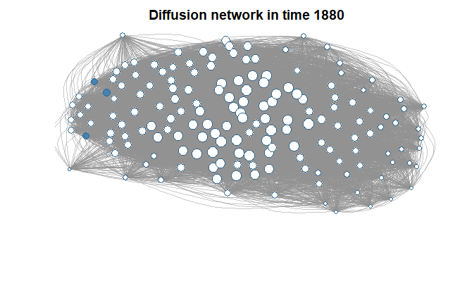

```r
plot(diffnet_culture)
```

```r
summary(diffnet_culture)
```

```
Diffusion network summary statistics
Name     : Diffusion Network
Behavior : Unspecified
-----------------------------------------------------------------------------
 Period   Adopters   Cum Adopt. (%)   Hazard Rate   Density   Moran's I (sd)
-------- ---------- ---------------- ------------- --------- ----------------
    1880          3         3 (0.02)             -      0.77 -0.00 (0.00) *
    1881          0         3 (0.02)          0.00      0.77 -0.00 (0.00)
    1882          0         3 (0.02)          0.00      0.77 -0.00 (0.00) *
    1883          0         3 (0.02)          0.00      0.76 -0.00 (0.00) *
    1884          0         3 (0.02)          0.00      0.76 -0.00 (0.00) *
    1885          0         3 (0.02)          0.00      0.76 -0.00 (0.00) *
    1886          0         3 (0.02)          0.00      0.76 -0.00 (0.00) *
    1887          1         4 (0.02)          0.01      0.76 -0.00 (0.00) ***
    1888          0         4 (0.02)          0.00      0.76 -0.00 (0.00) ***
```

[output cut: 129 more lines]

```r
# -------------------------------------------------------------------------
# -- 5. get the respective exposure variables and time-of-adoption (toa)
# -- generate exposure and add to diffnet object
diffnet_culture[["lag_w_expo_culture"]] <- exposure(diffnet_culture, valued = T, lags = 1)#
diffnet_culture[["lag_expo_culture"]] <- exposure(diffnet_culture, valued = F, lags = 1)
diffnet_culture[["adopted"]]  <- toa_mat(diffnet_culture)$cumadopt

table(data.frame(diffnet_culture)$adopted) # don't care about no. adopted here
```

```
    0     1
 9611 11873
```

```r
summary(data.frame(diffnet_culture)$lag_w_expo_culture)
```

```
   Min. 1st Qu.  Median    Mean 3rd Qu.    Max.    NA's
 0.0000  0.1860  0.6770  0.5515  0.8665  0.9699     164
```

```r
head(data.frame(diffnet_culture)) # exposure is NA for 1st 164 cases => 1880
```

|  | per | toa | gdp | regime | toa_unemp_A02 | toa_ILO_A03 | toa_HCS_A04 | toa_sickn_A04 | toa_comp_edu_A05 | toa_ml_A06 | toa_fa_A06 | existence | lag_w_expo_culture | lag_expo_culture | adopted | id |
| --- | --- | --- | --- | --- | --- | --- | --- | --- | --- | --- | --- | --- | --- | --- | --- | --- |
| 1 | 1880 | 1946 | 1283.126 | 0 | NA | 1969 | NA | NA | 1931 | 1987 | NA | 0 | NA | NA | 0 | AFG |
| 2 | 1880 | 1990 | 1893.869 | 0 | NA | 1976 | 1975 | NA | 1975 | NA | 2011 | 0 | NA | NA | 0 | AGO |
| 3 | 1880 | 1947 | 1065.000 | 0 | NA | 1997 | 1946 | 1947 | 1913 | 1947 | 1947 | 0 | NA | NA | 0 | ALB |
| 4 | 1880 | 1980 | 37556.320 | 0 | NA | 2001 | NA | NA | 1971 | 1980 | NA | 0 | NA | NA | 0 | ARE |
| 5 | 1880 | 1915 | 2748.000 | 0 | 1991 | 1968 | 1944 | 1934 | 1884 | 1934 | 1957 | 1 | NA | NA | 0 | ARG |
| 6 | 1880 | 1922 | 3136.225 | 0 | NA | 1994 | 1912 | 1912 | 1920 | 1956 | 1936 | 0 | NA | NA | 0 | ARM |

```r
tail(data.frame(diffnet_culture))
```

|  | per | toa | gdp | regime | toa_unemp_A02 | toa_ILO_A03 | toa_HCS_A04 | toa_sickn_A04 | toa_comp_edu_A05 | toa_ml_A06 | toa_fa_A06 | existence | lag_w_expo_culture | lag_expo_culture | adopted | id |
| --- | --- | --- | --- | --- | --- | --- | --- | --- | --- | --- | --- | --- | --- | --- | --- | --- |
| 21479 | 2010 | 1928 | 16161 | 3 | 1985 | 1971 | NA | NA | 1880 | 1940 | NA | 1 | 0.9361702 | 0.9276316 | 1 | VEN |
| 21480 | 2010 | 1936 | 4465 | 0 | 2006 | 1997 | NA | NA | 1967 | 1964 | NA | 1 | 0.9285714 | 0.9174312 | 1 | VNM |
| 21481 | 2010 | 1991 | 4363 | 3 | NA | 1969 | NA | NA | 1991 | 1995 | NA | 1 | 0.9250814 | 0.9047619 | 1 | YEM |
| 21482 | 2010 | 1914 | 11288 | 8 | 1937 | 1997 | NA | NA | 1953 | 1918 | 1992 | 1 | 0.9005376 | 0.9200000 | 1 | ZAF |
| 21483 | 2010 | 1929 | 2900 | 5 | NA | 1979 | NA | NA | 1966 | 1965 | NA | 1 | 0.9084967 | 0.9236111 | 1 | ZMB |
| 21484 | 2010 | 1920 | 1425 | 3 | NA | 1999 | NA | NA | 1938 | 1985 | NA | 1 | 0.8992042 | 0.9240506 | 1 | ZWE |

```r
# -------------------------
# - 4b) colonial ties -----
# -------------------------
# - here comes the core: creating the diffnet object
head(colonial_ties_edgelist)
```

|  | ego_id | alter_id | colony | year |
| --- | --- | --- | --- | --- |
| 1 | AFG | AGO | 0 | 1880 |
| 2 | AFG | ALB | 0 | 1880 |
| 3 | AFG | ARE | 0 | 1880 |
| 4 | AFG | ARG | 0 | 1880 |
| 5 | AFG | ARM | 0 | 1880 |
| 6 | AFG | AUS | 0 | 1880 |

```r
dim(colonial_ties_edgelist)
```

```
[1] 3501892       4
```

```r
diffnet_colony <- edgelist_to_diffnet(
  edgelist = colonial_ties_edgelist[,1:2], # As usual, a two column dataset [,1:2]
  w        = colonial_ties_edgelist$colony,
  t0       = colonial_ties_edgelist$year,  # An integer vector with starting point of spell
  t1       = colonial_ties_edgelist$year,  # An integer vector with the endpoint of spell
  undirected = TRUE,        # !!! change for >directed< network !!! => we provide it later
  dat      = covar,         # Attributes dataset
  idvar    = "iso3",
  toavar   = "toa_workinj_A02",          # -- !! here just change time-of-adoption !! -- #
  timevar  = "year",
  keep.isolates = TRUE    # Keeping isolates (if there's any)
)
```

```
Coercing -toa_workinj_A02- into integer.Coercing -ego_id- into character.Coercing -alter_id- into character.
```

```r
diffnet_colony
```

```
Dynamic network of class -diffnet-
 Name               : Diffusion Network
 Behavior           : Unspecified
 # of nodes         : 164 (AFG, AGO, ALB, ARE, ARG, ARM, AUS, AUT, ...)
 # of time periods  : 131 (1880 - 2010)
 Type               : undirected
 Final prevalence   : 0.93
 Static attributes  : -
 Dynamic attributes : gdp, regime, toa_unemp_A02, toa_ILO_A03, toa_HCS_A... (10)
```

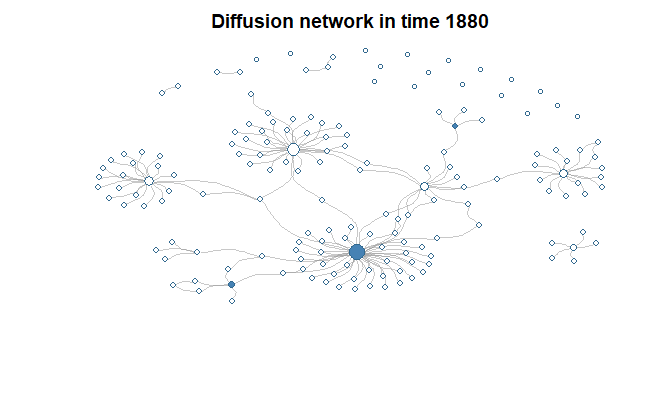

```r
plot(diffnet_colony)
```

```r
summary(diffnet_colony)
```

```
Diffusion network summary statistics
Name     : Diffusion Network
Behavior : Unspecified
-----------------------------------------------------------------------------
 Period   Adopters   Cum Adopt. (%)   Hazard Rate   Density   Moran's I (sd)
-------- ---------- ---------------- ------------- --------- ----------------
    1880          3         3 (0.02)             -      0.01 -0.01 (0.02)
    1881          0         3 (0.02)          0.00      0.01 -0.01 (0.02)
    1882          0         3 (0.02)          0.00      0.01 -0.01 (0.02)
    1883          0         3 (0.02)          0.00      0.01 -0.01 (0.02)
    1884          0         3 (0.02)          0.00      0.01 -0.01 (0.02)
    1885          0         3 (0.02)          0.00      0.01 -0.01 (0.02)
    1886          0         3 (0.02)          0.00      0.01 -0.01 (0.02)
    1887          1         4 (0.02)          0.01      0.01 -0.02 (0.02)
    1888          0         4 (0.02)          0.00      0.01 -0.02 (0.02)
```

[output cut: 129 more lines]

```r
# -------------------------------------------------------------------------
# -- 5. get the respective exposure variables and time-of-adoption (toa)
# compute exposure: Netdiffuser automatically identifies whether the input is dynamic or not.
diffnet_colony[["lag_w_expo_colony"]] <- exposure(diffnet_colony, valued = T, lags = 1)
diffnet_colony[["lag_expo_colony"]] <- exposure(diffnet_colony, valued = F, lags = 1)

diffnet_colony[["adopted"]]  <- toa_mat(diffnet_colony)$cumadopt

diffnet_colony
```

```
Dynamic network of class -diffnet-
 Name               : Diffusion Network
 Behavior           : Unspecified
 # of nodes         : 164 (AFG, AGO, ALB, ARE, ARG, ARM, AUS, AUT, ...)
 # of time periods  : 131 (1880 - 2010)
 Type               : undirected
 Final prevalence   : 0.93
 Static attributes  : -
 Dynamic attributes : gdp, regime, toa_unemp_A02, toa_ILO_A03, toa_HCS_A... (13)
```

```r
summary(diffnet_colony)
```

```
Diffusion network summary statistics
Name     : Diffusion Network
Behavior : Unspecified
-----------------------------------------------------------------------------
 Period   Adopters   Cum Adopt. (%)   Hazard Rate   Density   Moran's I (sd)
-------- ---------- ---------------- ------------- --------- ----------------
    1880          3         3 (0.02)             -      0.01 -0.01 (0.02)
    1881          0         3 (0.02)          0.00      0.01 -0.01 (0.02)
    1882          0         3 (0.02)          0.00      0.01 -0.01 (0.02)
    1883          0         3 (0.02)          0.00      0.01 -0.01 (0.02)
    1884          0         3 (0.02)          0.00      0.01 -0.01 (0.02)
    1885          0         3 (0.02)          0.00      0.01 -0.01 (0.02)
    1886          0         3 (0.02)          0.00      0.01 -0.01 (0.02)
    1887          1         4 (0.02)          0.01      0.01 -0.02 (0.02)
    1888          0         4 (0.02)          0.00      0.01 -0.02 (0.02)
```

[output cut: 129 more lines]

```r
summary(data.frame(diffnet_colony)$lag_w_expo_colony)
```

```
   Min. 1st Qu.  Median    Mean 3rd Qu.    Max.    NA's
 0.0000  0.5000  1.0000  0.7532  1.0000  1.0000     164
```

```r
# -------------------------
# - 4c) trade network -----
# -------------------------
# - here comes the core: creating the diffnet object
head(trade_edgelist)
```

|  | ego_id | alter_id | year | smoothtotrade | log_value |
| --- | --- | --- | --- | --- | --- |
| 1 | AFG | AGO | 1880 | 0 | 0 |
| 2 | AFG | AGO | 1881 | 0 | 0 |
| 3 | AFG | AGO | 1882 | 0 | 0 |
| 4 | AFG | AGO | 1883 | 0 | 0 |
| 5 | AFG | AGO | 1884 | 0 | 0 |
| 6 | AFG | AGO | 1885 | 0 | 0 |

```r
dim(trade_edgelist)
```

```
[1] 3501892       5
```

```r
diffnet_trade <- edgelist_to_diffnet(
  edgelist = trade_edgelist[,1:2], # As usual, a two column dataset [,1:2]
  t0       = trade_edgelist$year,  # An integer vector with starting point of spell
  t1       = trade_edgelist$year,  # An integer vector with the endpoint of spell
  w        = trade_edgelist$log_value,
  undirected = TRUE,        # undirected network
  dat      = covar,         # Attributes dataset
  idvar    = "iso3",
  toavar   = "toa_workinj_A02",          # -- !! here just change time-of-adoption !! -- #
  timevar  = "year",
  keep.isolates = TRUE    # Keeping isolates (if there's any)
)
```

```
Coercing -toa_workinj_A02- into integer.Coercing -ego_id- into character.Coercing -alter_id- into character.
```

```r
diffnet_trade
```

```
Dynamic network of class -diffnet-
 Name               : Diffusion Network
 Behavior           : Unspecified
 # of nodes         : 164 (AFG, AGO, ALB, ARE, ARG, ARM, AUS, AUT, ...)
 # of time periods  : 131 (1880 - 2010)
 Type               : undirected
 Final prevalence   : 0.93
 Static attributes  : -
 Dynamic attributes : gdp, regime, toa_unemp_A02, toa_ILO_A03, toa_HCS_A... (10)
```

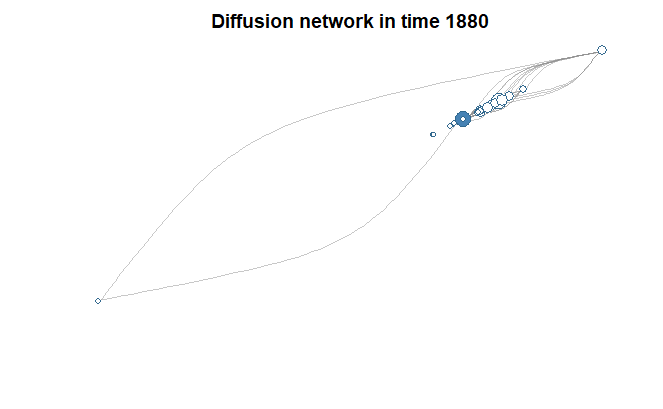

```r
plot(diffnet_trade)
```

```r
summary(diffnet_trade)
```

```
Diffusion network summary statistics
Name     : Diffusion Network
Behavior : Unspecified
-----------------------------------------------------------------------------
 Period   Adopters   Cum Adopt. (%)   Hazard Rate   Density   Moran's I (sd)
-------- ---------- ---------------- ------------- --------- ----------------
    1880          3         3 (0.02)             -      0.01  0.22 (0.03) ***
    1881          0         3 (0.02)          0.00      0.01  0.23 (0.03) ***
    1882          0         3 (0.02)          0.00      0.01  0.16 (0.03) ***
    1883          0         3 (0.02)          0.00      0.01  0.19 (0.03) ***
    1884          0         3 (0.02)          0.00      0.01  0.18 (0.03) ***
    1885          0         3 (0.02)          0.00      0.01  0.17 (0.03) ***
    1886          0         3 (0.02)          0.00      0.01  0.20 (0.03) ***
    1887          1         4 (0.02)          0.01      0.01  0.08 (0.03) ***
    1888          0         4 (0.02)          0.00      0.01  0.04 (0.03)
```

[output cut: 129 more lines]

```r
# -------------------------------------------------------------------------
# -- 5. get the respective exposure variables and time-of-adoption (toa)
# compute exposure: Netdiffuser automatically identifies whether the input is dynamic or not.
diffnet_trade[["lag_w_expo_trade"]] <- exposure(diffnet_trade, valued = T, lags = 1)
diffnet_trade[["lag_expo_trade"]] <- exposure(diffnet_trade, valued = F, lags = 1)

diffnet_trade[["adopted"]]  <- toa_mat(diffnet_trade)$cumadopt

head(data.frame(diffnet_trade))
```

|  | per | toa | gdp | regime | toa_unemp_A02 | toa_ILO_A03 | toa_HCS_A04 | toa_sickn_A04 | toa_comp_edu_A05 | toa_ml_A06 | toa_fa_A06 | existence | lag_w_expo_trade | lag_expo_trade | adopted | id |
| --- | --- | --- | --- | --- | --- | --- | --- | --- | --- | --- | --- | --- | --- | --- | --- | --- |
| 1 | 1880 | 1946 | 1283.126 | 0 | NA | 1969 | NA | NA | 1931 | 1987 | NA | 0 | NA | NA | 0 | AFG |
| 2 | 1880 | 1990 | 1893.869 | 0 | NA | 1976 | 1975 | NA | 1975 | NA | 2011 | 0 | NA | NA | 0 | AGO |
| 3 | 1880 | 1947 | 1065.000 | 0 | NA | 1997 | 1946 | 1947 | 1913 | 1947 | 1947 | 0 | NA | NA | 0 | ALB |
| 4 | 1880 | 1980 | 37556.320 | 0 | NA | 2001 | NA | NA | 1971 | 1980 | NA | 0 | NA | NA | 0 | ARE |
| 5 | 1880 | 1915 | 2748.000 | 0 | 1991 | 1968 | 1944 | 1934 | 1884 | 1934 | 1957 | 1 | NA | NA | 0 | ARG |
| 6 | 1880 | 1922 | 3136.225 | 0 | NA | 1994 | 1912 | 1912 | 1920 | 1956 | 1936 | 0 | NA | NA | 0 | ARM |

```r
tail(data.frame(diffnet_trade))
```

|  | per | toa | gdp | regime | toa_unemp_A02 | toa_ILO_A03 | toa_HCS_A04 | toa_sickn_A04 | toa_comp_edu_A05 | toa_ml_A06 | toa_fa_A06 | existence | lag_w_expo_trade | lag_expo_trade | adopted | id |
| --- | --- | --- | --- | --- | --- | --- | --- | --- | --- | --- | --- | --- | --- | --- | --- | --- |
| 21479 | 2010 | 1928 | 16161 | 3 | 1985 | 1971 | NA | NA | 1880 | 1940 | NA | 1 | 0.9314859 | 0.9504132 | 1 | VEN |
| 21480 | 2010 | 1936 | 4465 | 0 | 2006 | 1997 | NA | NA | 1967 | 1964 | NA | 1 | 0.9454572 | 0.9444444 | 1 | VNM |
| 21481 | 2010 | 1991 | 4363 | 3 | NA | 1969 | NA | NA | 1991 | 1995 | NA | 1 | 0.9991107 | 0.9338843 | 1 | YEM |
| 21482 | 2010 | 1914 | 11288 | 8 | 1937 | 1997 | NA | NA | 1953 | 1918 | 1992 | 1 | 0.9431262 | 0.9333333 | 1 | ZAF |
| 21483 | 2010 | 1929 | 2900 | 5 | NA | 1979 | NA | NA | 1966 | 1965 | NA | 1 | 0.8883735 | 0.9343066 | 1 | ZMB |
| 21484 | 2010 | 1920 | 1425 | 3 | NA | 1999 | NA | NA | 1938 | 1985 | NA | 1 | 0.8996494 | 0.9230769 | 1 | ZWE |

```r
summary(data.frame(diffnet_trade)$lag_w_expo_trade)
```

```
     Min.   1st Qu.    Median      Mean   3rd Qu.      Max.      NA's
-348.0213    0.0000    0.4890    0.4603    0.9264  476.4145       164
```

```r
# -----------------------------
# - 4d) spatial proximity -----
# -----------------------------
# - here comes the core: creating the diffnet object
head(capital_distance_edgelist)
```

|  | ego_id | alter_id | year | proximity |
| --- | --- | --- | --- | --- |
| 1 | AFG | AGO | 1880 | 1.316995e-04 |
| 2 | AFG | ALB | 1880 | 2.300787e-04 |
| 3 | AFG | ARE | 1880 | 5.511274e-04 |
| 4 | AFG | ARG | 1880 | 6.536803e-05 |
| 5 | AFG | ARM | 1880 | 4.413011e-04 |
| 6 | AFG | AUS | 1880 | 8.825012e-05 |

```r
dim(capital_distance_edgelist)
```

```
[1] 3501892       4
```

```r
diffnet_proximity <- edgelist_to_diffnet(
  edgelist = capital_distance_edgelist[,1:2], # As usual, a two column dataset [,1:2]
  t0       = capital_distance_edgelist$year,  # An integer vector with starting point of spell
  t1       = capital_distance_edgelist$year,  # An integer vector with the endpoint of spell
  w        = capital_distance_edgelist$proximity,
  undirected = TRUE,        # undirected network
  dat      = covar,         # Attributes dataset
  idvar    = "iso3",
  toavar   = "toa_workinj_A02",          # -- !! here just change time-of-adoption !! -- #
  timevar  = "year",
  keep.isolates = TRUE    # Keeping isolates (if there's any)
)
```

```
Coercing -toa_workinj_A02- into integer.Coercing -ego_id- into character.Coercing -alter_id- into character.
```

```r
diffnet_proximity
```

```
Dynamic network of class -diffnet-
 Name               : Diffusion Network
 Behavior           : Unspecified
 # of nodes         : 164 (AFG, AGO, ALB, ARE, ARG, ARM, AUS, AUT, ...)
 # of time periods  : 131 (1880 - 2010)
 Type               : undirected
 Final prevalence   : 0.93
 Static attributes  : -
 Dynamic attributes : gdp, regime, toa_unemp_A02, toa_ILO_A03, toa_HCS_A... (10)
```

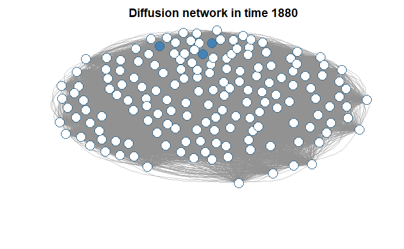

```r
plot(diffnet_proximity)
```

```r
summary(diffnet_proximity) # - moran's I seems to be insignificant regarding
```

```
Diffusion network summary statistics
Name     : Diffusion Network
Behavior : Unspecified
-----------------------------------------------------------------------------
 Period   Adopters   Cum Adopt. (%)   Hazard Rate   Density   Moran's I (sd)
-------- ---------- ---------------- ------------- --------- ----------------
    1880          3         3 (0.02)             -      1.00               -
    1881          0         3 (0.02)          0.00      1.00               -
    1882          0         3 (0.02)          0.00      1.00               -
    1883          0         3 (0.02)          0.00      1.00               -
    1884          0         3 (0.02)          0.00      1.00               -
    1885          0         3 (0.02)          0.00      1.00               -
    1886          0         3 (0.02)          0.00      1.00               -
    1887          1         4 (0.02)          0.01      1.00               -
    1888          0         4 (0.02)          0.00      1.00               -
```

[output cut: 129 more lines]

```r
                           # - >unweighted< geodesic distance in network.
                           # - Unweighted network density is 100% => it's not a variable
                           # - but see hazard model below with
                           # - with >exposure< by >weighted< distances!

diffnet_proximity[["lag_w_expo_proximity"]] <- exposure(diffnet_proximity, valued = T, lags = 1)

diffnet_proximity[["lag_expo_proximity"]] <- exposure(diffnet_proximity, valued = F, lags = 1)

diffnet_proximity[["adopted"]]  <- toa_mat(diffnet_proximity)$cumadopt

diffnet_proximity
```

```
Dynamic network of class -diffnet-
 Name               : Diffusion Network
 Behavior           : Unspecified
 # of nodes         : 164 (AFG, AGO, ALB, ARE, ARG, ARM, AUS, AUT, ...)
 # of time periods  : 131 (1880 - 2010)
 Type               : undirected
 Final prevalence   : 0.93
 Static attributes  : -
 Dynamic attributes : gdp, regime, toa_unemp_A02, toa_ILO_A03, toa_HCS_A... (13)
```

```r
summary(data.frame(diffnet_proximity)$lag_expo_proximity)
```

```
   Min. 1st Qu.  Median    Mean 3rd Qu.    Max.    NA's
0.01227 0.19632 0.66258 0.54977 0.87117 0.93252     164
```

```r
head(data.frame(diffnet_proximity))
```

|  | per | toa | gdp | regime | toa_unemp_A02 | toa_ILO_A03 | toa_HCS_A04 | toa_sickn_A04 | toa_comp_edu_A05 | toa_ml_A06 | toa_fa_A06 | existence | lag_w_expo_proximity | lag_expo_proximity | adopted | id |
| --- | --- | --- | --- | --- | --- | --- | --- | --- | --- | --- | --- | --- | --- | --- | --- | --- |
| 1 | 1880 | 1946 | 1283.126 | 0 | NA | 1969 | NA | NA | 1931 | 1987 | NA | 0 | NA | NA | 0 | AFG |
| 2 | 1880 | 1990 | 1893.869 | 0 | NA | 1976 | 1975 | NA | 1975 | NA | 2011 | 0 | NA | NA | 0 | AGO |
| 3 | 1880 | 1947 | 1065.000 | 0 | NA | 1997 | 1946 | 1947 | 1913 | 1947 | 1947 | 0 | NA | NA | 0 | ALB |
| 4 | 1880 | 1980 | 37556.320 | 0 | NA | 2001 | NA | NA | 1971 | 1980 | NA | 0 | NA | NA | 0 | ARE |
| 5 | 1880 | 1915 | 2748.000 | 0 | 1991 | 1968 | 1944 | 1934 | 1884 | 1934 | 1957 | 1 | NA | NA | 0 | ARG |
| 6 | 1880 | 1922 | 3136.225 | 0 | NA | 1994 | 1912 | 1912 | 1920 | 1956 | 1936 | 0 | NA | NA | 0 | ARM |

```r
# - save first diffnet object as data as data frame
diff_data_culture <- as.data.frame(diffnet_culture)
head(diff_data_culture)
```

|  | per | toa | gdp | regime | toa_unemp_A02 | toa_ILO_A03 | toa_HCS_A04 | toa_sickn_A04 | toa_comp_edu_A05 | toa_ml_A06 | toa_fa_A06 | existence | lag_w_expo_culture | lag_expo_culture | adopted | id |
| --- | --- | --- | --- | --- | --- | --- | --- | --- | --- | --- | --- | --- | --- | --- | --- | --- |
| 1 | 1880 | 1946 | 1283.126 | 0 | NA | 1969 | NA | NA | 1931 | 1987 | NA | 0 | NA | NA | 0 | AFG |
| 2 | 1880 | 1990 | 1893.869 | 0 | NA | 1976 | 1975 | NA | 1975 | NA | 2011 | 0 | NA | NA | 0 | AGO |
| 3 | 1880 | 1947 | 1065.000 | 0 | NA | 1997 | 1946 | 1947 | 1913 | 1947 | 1947 | 0 | NA | NA | 0 | ALB |
| 4 | 1880 | 1980 | 37556.320 | 0 | NA | 2001 | NA | NA | 1971 | 1980 | NA | 0 | NA | NA | 0 | ARE |
| 5 | 1880 | 1915 | 2748.000 | 0 | 1991 | 1968 | 1944 | 1934 | 1884 | 1934 | 1957 | 1 | NA | NA | 0 | ARG |
| 6 | 1880 | 1922 | 3136.225 | 0 | NA | 1994 | 1912 | 1912 | 1920 | 1956 | 1936 | 0 | NA | NA | 0 | ARM |

```r
table(diff_data_culture$adopted) # don't care about n. of cases
```

```
    0     1
 9611 11873
```